# Cyclistic - Market Insights Case Study

## Determine bike preference based on member

```r
bike_pref_df <- clean_df %>%
  group_by(member_casual, rideable_type) %>%
  summarize(total_bike_type_used = n(), .groups='drop') %>%
  group_by(member_casual) %>%
  mutate(percent_to_total = total_bike_type_used / sum(total_bike_type_used))

head(bike_pref_df)
```

```
## # A tibble: 5 × 4
## # Groups:   member_casual [2]
##   member_casual rideable_type total_bike_type_used percent_to_total
##   <chr>         <chr>                        <int>            <dbl>
## 1 casual        classic_bike                869063           0.423
## 2 casual        docked_bike                  80212           0.0391
## 3 casual        electric_bike              1103053           0.537
## 4 member        classic_bike               1795702           0.495
## 5 member        electric_bike              1829454           0.505
```

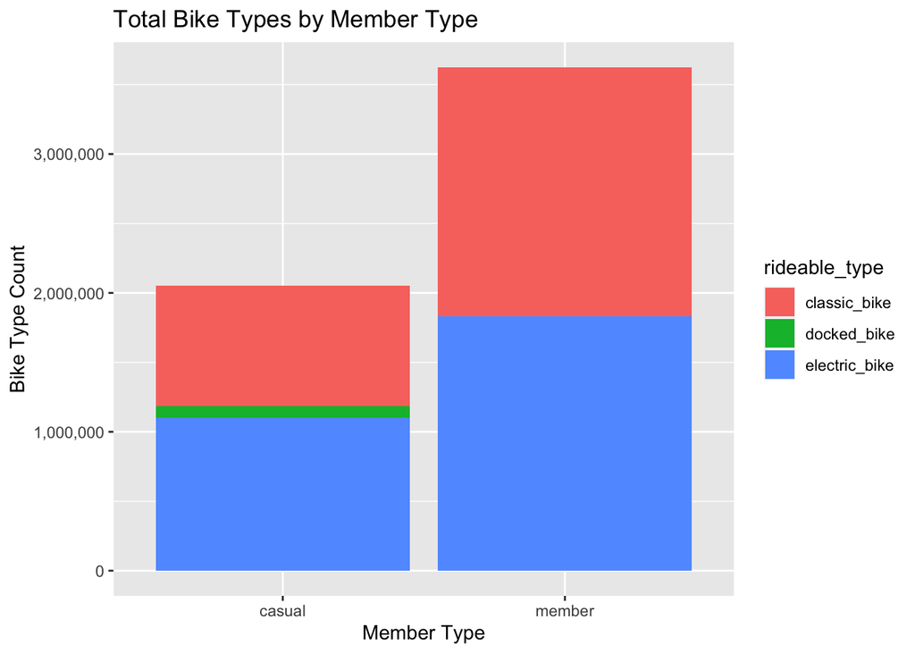

```r
ggplot(bike_pref_df) + geom_col(mapping = aes(x = member_casual, y = total_bike_type_used, fill = rideable_type)) +
labs(title = "Total Bike Types by Member Type", x = "Member Type", y = "Bike Type Count") +
scale_y_continuous(labels = label_comma())
```

```r
DT::datatable(bike_pref_df)
```

|  | member_casual | rideable_type | total_bike_type_used | percent_to_total |
| --- | --- | --- | --- | --- |
| 1 | casual | classic_bike | 869063 | 0.4234522941752001 |
| 2 | casual | docked_bike | 80212 | 0.03908342136344678 |
| 3 | casual | electric_bike | 1103053 | 0.5374642844613532 |
| 4 | member | classic_bike | 1795702 | 0.4953447520603251 |
| 5 | member | electric_bike | 1829454 | 0.5046552479396749 |

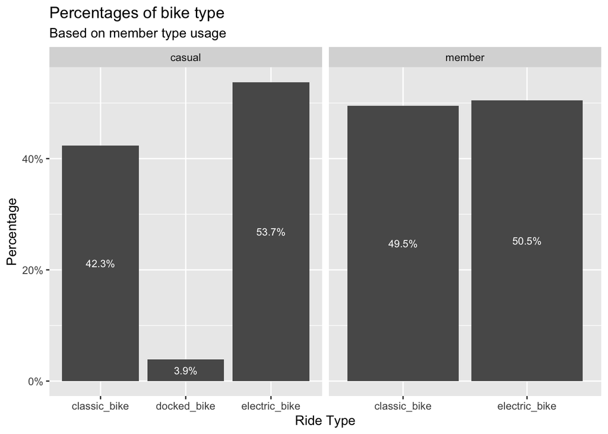

```r
ggplot(bike_pref_df) + geom_col(mapping = aes(x = rideable_type, y = percent_to_total, label = scales::percent(percent_to_total, accuracy = 0.1))) +
geom_text(aes(x = rideable_type, y = percent_to_total, label = scales::percent(percent_to_total, accuracy = 0.1)),
  position = position_stack(vjust = 0.5), #this will center the labels inside the bars
  color = "white", #this is the text inside. Needs to be a color that stands out for visibility
  size = 3) +
facet_wrap(~member_casual, scales = "free_x") +
scale_y_continuous(labels = scales::percent_format(accuracy = 1)) +
labs(title = "Percentages of bike type", subtitle = "Based on member type usage", x = "Ride Type", y = "Percentage")
```

The following insights were found: * Electric bikes are preferred by a higher percentage of casual riders compared to members, possibly due to the ease of riding and novelty. * Members’ bike type usage is fairly balanced between classic and electric bikes, which could reflect a more practical approach to bike selection.

## Recommendations based on analysis

Through the insights found through our analysis, and the patterns that are exhibited between casual vs annual members we can create a deeper understanding to the drivers of usage, reasons for member type, and potential options to create conversion to annual members.

### Differences between Casual Riders and Annual Members

- Annual Members: They use the bikes more consistently throughout the week, suggesting that the bikes are part of their regular routine, likely for commuting to work or school. Their trip lengths are relatively stable, indicating a pattern of regular, predictable use.
- Casual Riders: They predominantly use bikes on weekends and for longer periods, especially in warmer months, which implies recreational use or as a transportation method during leisure activities. Their preference for electric bikes and the concentration of trips at specific stations suggest they use the service for occasional exploration or tourism.

### Reasons Casual Riders may look to buy Cyclistic Annual Memberships

- Cost Savings: Casual riders who use the service frequently enough may find that an annual membership is more cost-effective than paying per ride.
- Convenience: Membership could offer additional benefits such as expedited bike checkout, which could be appealing for frequent use.
- Commitment to Health and Environment: Riders may be motivated to switch to a more sustainable mode of transportation that also offers health benefits, aligning with personal or social values.
- Incentives and Promotions: Targeted promotions for casual riders, such as discounted trial memberships or exclusive member benefits, could entice them to try out and ultimately commit to an annual membership.

### Potential implementations using Digital Media to Spur Casual Rider conversion

- Targeted Advertising: Use data insights to create targeted ad campaigns for casual riders on platforms they frequent. Highlight the benefits of membership, especially during peak usage times like weekends and summer months.
- Engagement Campaigns: Run social media campaigns that engage casual riders with challenges, incentives, and shareable content to create a sense of community they might want to join.
- Content Marketing: Develop content that showcases the benefits of switching to annual membership, including member testimonials, cost comparison calculators, and the environmental impact of cycling versus driving.
- Email Marketing: Implement an email nurture campaign that provides casual riders with personalized content and special offers to encourage membership sign-up.
- Analytics-Driven Insights: Utilize user engagement and conversion data to continually refine digital strategies, ensuring the marketing efforts are effective and efficient.

## Conclusion

The analysis of Cyclistic’s data has depicted clear distincions in usage patterns between annual members and it’s casual members. Annual members consistently utilize the ride-share service for daily commute and transportation. In contrast casual riders primarily use the service during weekends and warmer months, with longer trips during this time, suggesting recreational, explorational or tourism reasons.

As a potential opportunity to convert, the casual rider demographic bolsters a multifacted approach to the percieved opportunity. Economic, convenience and environmental incentives take to the forefront as some reasons that casual riders can be motivated by. To appease to these opportunities, the use of digital media and marketing, and how it’s leveraged will be key to influencing these users

To capitalize on these insights, Cyclistic is recommended to implement targeted digital marketing campaigns that align with casual riders’ habits, harness the power of engaging content to communicate the value of memberships, and utilize analytical tools to refine marketing approaches continually. By focusing on the convenience, cost savings, and additional benefits that come with membership, along with a robust digital presence that resonates with casual riders’ values and preferences, Cyclistic can create a compelling proposition for converting casual riders to loyal members.

In summary, the path forward for Cyclistic involves a combination of strategic promotions, value-driven communication, and enhanced digital engagement, all informed by the rich data insights at their disposal. Through concerted efforts in these areas, Cyclistic can expect to see a stronger community of annual members, thereby driving growth and fostering a more sustainable, health-conscious mode of transportation within the community